# Untitled

Emanuel Rodriguez

5/17/2022

## Objective

Our objective in this analysis is to provide a new set of spawning habitat values for the DSM models. These updated habitat amounts will incorporate real flow data.

## Flow to Sediment Transport Curves

Flow to sediment transport curves were created using an SRH2D model developed for the Upper Sacramento River.

```r
g <- gt(rating_curves_by_rm %>% head()) %>%
  gt::cols_label(flow = "Flow (cfs)",
                 parker_qs = "Parker",
                 wilcock_qs = "Wilcock",
                 gaeuman_qs = "Gaeuman",
                 river_mile = "River Mile")
```

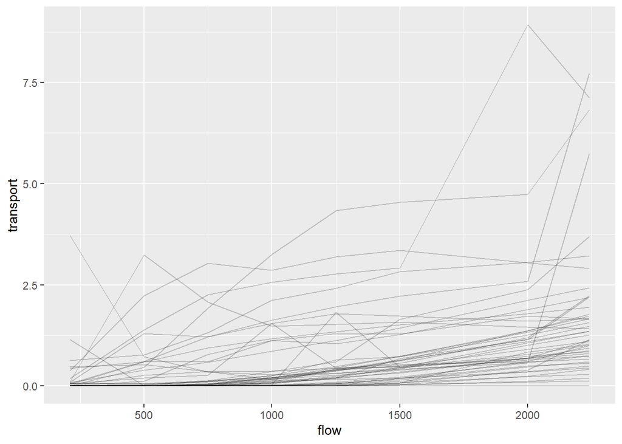

```r
rating_curves_by_rm %>%
  pivot_longer(values_to = "transport",
               names_to = "curve",
               parker_qs:gaeuman_qs) %>%
  filter(curve == "parker_qs") %>%
  ggplot(aes(flow, transport, group = river_mile)) +
  geom_line(alpha=.2)
```

### Summarizing to a Single Transport Curve

*Note: our choice choosing the minimum in the first summary above is somewhat arbitraty and can be easily updated*

```r
rating_curve <- rating_curves_by_rm %>%
  rename(flow_cms = flow) %>%
  pivot_longer(parker_qs:gaeuman_qs, names_to = "curve", values_to = "transport_m3_per_second") %>%
  mutate(
    flow_cfs = 35.315 * flow_cms,
    flow_cfd = flow_cfs * 86400, # cubic feet per day
    transport_ft3_per_second = 35.315 * transport_m3_per_second,
    transport_ft3_per_day = 86400 * transport_ft3_per_second # transport per day
  ) %>%
  group_by(flow_cfs, river_mile) %>%
  summarise(
    sed_ft3_per_second_min = min(transport_ft3_per_second),
    sed_ft3_per_second_avg = mean(transport_ft3_per_second),
    sed_ft3_per_second_max = max(transport_ft3_per_second),
    sed_ft3_per_day_min = min(transport_ft3_per_day),
    sed_ft3_per_day_avg = mean(transport_ft3_per_day),
    sed_ft3_per_day_max = max(transport_ft3_per_day)
  ) %>%
  ungroup() %>%
  group_by(flow_cfs) %>%
  summarise(
    sed_ft3_per_second_min = mean(sed_ft3_per_second_min),
    sed_ft3_per_second_avg = mean(sed_ft3_per_second_avg),
    sed_ft3_per_second_max = mean(sed_ft3_per_second_max),
    sed_ft3_per_day_min = mean(sed_ft3_per_day_min),
    sed_ft3_per_day_avg = mean(sed_ft3_per_day_avg),
    sed_ft3_per_day_max = mean(sed_ft3_per_day_max),
  ) %>%
  ungroup() %>%
  mutate(flow_cfd = flow_cfs * 86400)
```

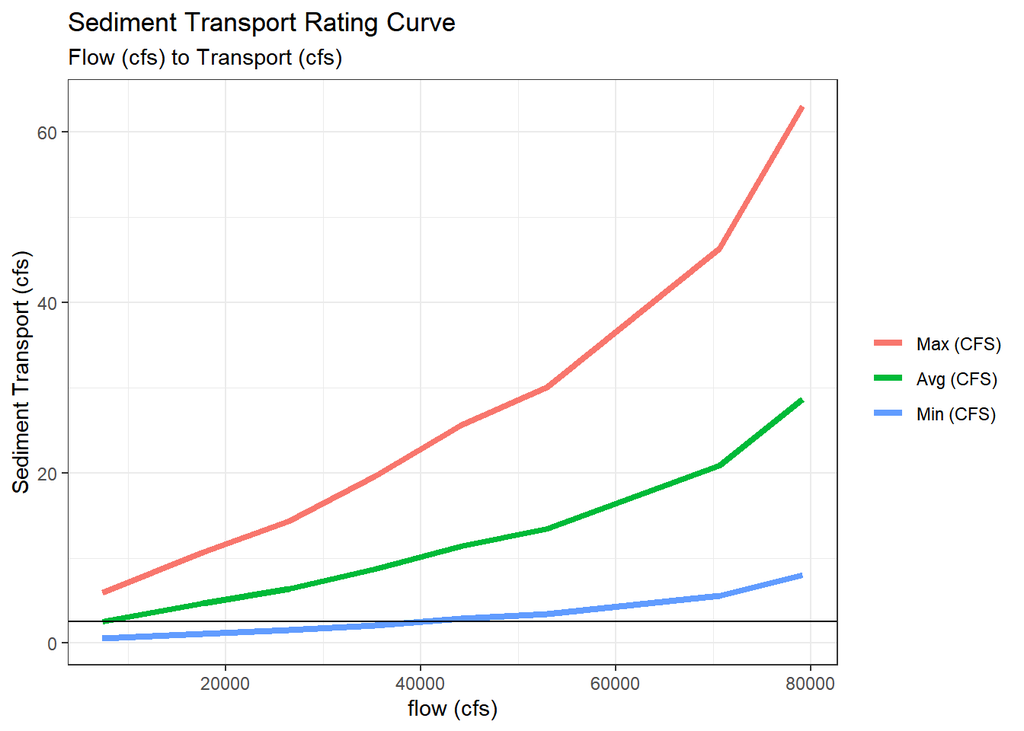

```r
rating_curve %>%
  pivot_longer(names_to = "curve",
               values_to = "sediment_transport",
               sed_ft3_per_second_min:sed_ft3_per_second_max) %>%
  mutate(
    curve_label = case_when(
      curve == "sed_ft3_per_second_min" ~ "Min (CFS)",
      curve == "sed_ft3_per_second_avg" ~ "Avg (CFS)",
      curve == "sed_ft3_per_second_max" ~ "Max (CFS)",
    ),
    curve_label = factor(curve_label,
                         levels = c(
                           "Max (CFS)",
                           "Avg (CFS)",
                           "Min (CFS)"
                         ))) %>%
  ggplot(aes(flow_cfs, sediment_transport, color = curve_label)) +
  geom_line(size = 1.5) +
  geom_hline(yintercept = 2.5) +
  theme(legend.position="bottom") +
  labs(x = "flow (cfs)", y = "Sediment Transport (cfs)",
       title = "Sediment Transport Rating Curve",
       subtitle = "Flow (cfs) to Transport (cfs)",
       color = NULL) +
  theme_bw()
```

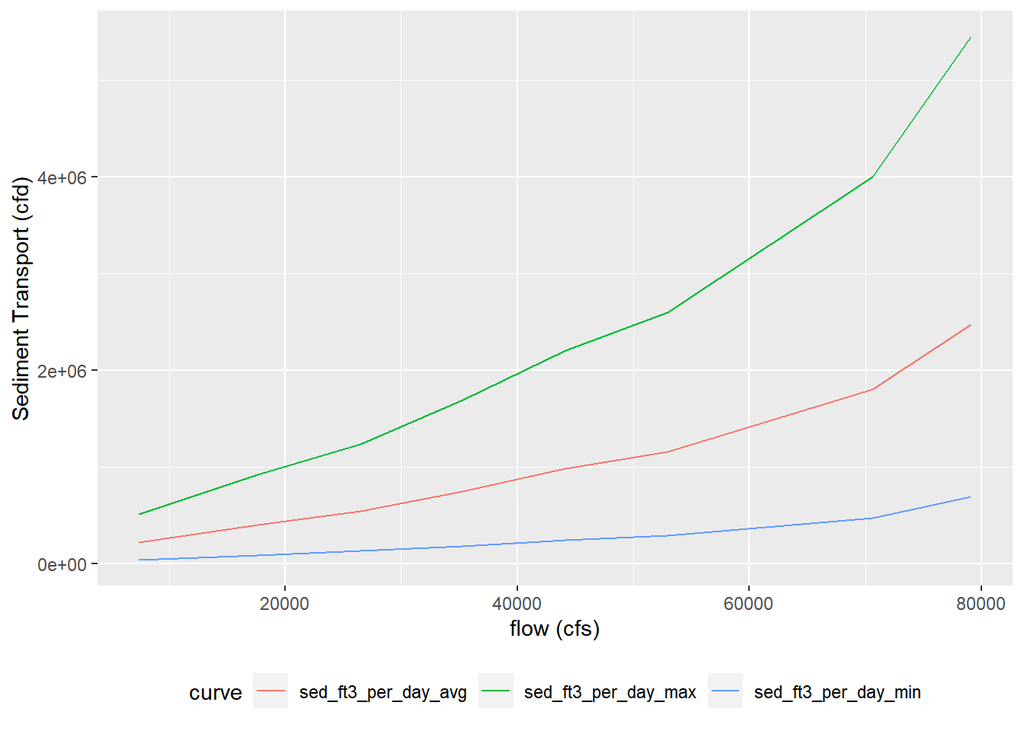

```r
rating_curve %>%
  pivot_longer(names_to = "curve",
               values_to = "sediment_transport",
               sed_ft3_per_day_min:sed_ft3_per_day_max) %>%
  ggplot(aes(flow_cfs, sediment_transport, color = curve)) +
  geom_line() +
  theme(legend.position="bottom") +
  labs(x = "flow (cfs)", y = "Sediment Transport (cfd)")
```

Using the relationship above we develop `approxfun`’s that allow us to interpolate any a transport value given any flow within the domain. We will be using USGS flow data to obtain daily transport values in the following section.

```
flow_cfs_to_sed_transport_cfs <- approxfun(
  x = rating_curve$flow_cfs,
  y = rating_curve$transport_ft3_per_second
)

flow_cfs_to_sed_transport_cfd <- approxfun(
  x = rating_curve$flow_cfs,
  y = rating_curve$transport_ft3_per_day
)
```

```r
flow_cfs_to_sed_transport_cfs <- approxfun(
  x = rating_curve$flow_cfs,
  y = rating_curve$sed_ft3_per_second_min
)

flow_cfs_to_sed_transport_cfd <- approxfun(
  x = rating_curve$flow_cfs,
  y = rating_curve$sed_ft3_per_day_min
)
```

## Flow Data

The flow data used to compute sediment transport values is obtained using the USGS `dataRetrieval` package. The following parameters were used:

- site_number: 11370500
- parameter_code: 00060 (flow in cfs)
- start_date: 1980-01-01
- end_date: 2022-01-01

```r
kwk_usgs <- dataRetrieval::readNWISdv("11370500", parameterCd = "00060", startDate = "1980-01-01",
                                      endDate = "2022-01-01") %>%
  dataRetrieval::renameNWISColumns() %>%
  as_tibble()
```

[figure not shown]

```r
kwk_usgs %>%
  ggplot(aes(Date, Flow)) +
  geom_line() +
  labs(x = "", y = "Daily Average Flow (Cfs)",
       title = "USGS Daily Average Flow at Keswick Dam (1980-2022")
```

[figure not shown]

```r
kwk_usgs %>%
  mutate(year_group = as.character(year(Date)),
         plot_date = `year<-`(Date, 2050)) %>%
  ggplot(aes(plot_date, Flow, group = year_group)) +
  geom_line(alpha=0.2) +
  scale_x_date(date_breaks = "1 month", date_labels = "%b") +
  theme_bw() +
  labs(x = "", y = "Daily Average Flow (Cfs)",
       title = "USGS Daily Average Flow at Keswick Dam (1980-2022")
```

[figure not shown]

```r
kwk_usgs %>%
  filter(Date >= "2015-01-01", Date <= "2017-04-01") %>%
    ggplot(aes(Date, Flow)) +
  geom_line() +
  labs(x = "", y = "Daily Average Flow (Cfs)",
       title = "USGS Daily Average Flow at Keswick Dam") +
  scale_x_date(date_labels = "%b-%y'",
               date_breaks = "3 months") +
  theme_bw()
```

The time series for flow data:

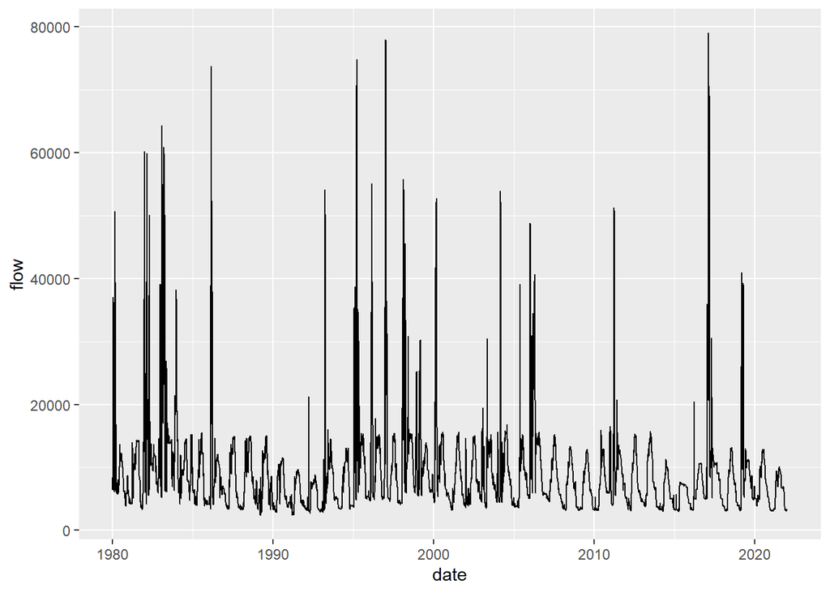

```r
kwk_sed_transport <- tibble(
  date = kwk_usgs$Date,
  flow = kwk_usgs$Flow,
  sediment_transport_f3_day = flow_cfs_to_sed_transport_cfd(flow)
) %>%
  mutate(sediment_transport_f3_day = ifelse(is.na(sediment_transport_f3_day), 0, sediment_transport_f3_day))

usgs_flow_plot <- ggplot(kwk_sed_transport, aes(date, flow)) + geom_line()

print(usgs_flow_plot)
```

### USGS Daily vs CALSIM

Ultimately we will need to convert the decay values from daily usgs to a monthly value that is compatible with the DSM models. Here we compare USGS flows summarized to a monthly mean vs the CALSIM values.

```r
calsim_flows <- DSMflow::upper_sacramento_flows %>%
  as_tibble() %>%
  mutate(month = 1:12) %>%
  pivot_longer(-month, names_to = "year", values_to = "flow_cms") %>%
  mutate(date = lubridate::as_date(paste0(year, "-", month, "-01")),
         year = as.numeric(year),
         flow_cfs = 35.315 * flow_cms)


kwk_monthly <- kwk_usgs %>%
  mutate(month = lubridate::month(Date), year = lubridate::year(Date)) %>%
  group_by(year, month) %>%
  summarise(
    usgs_flow_avg = mean(Flow, na.rm = TRUE),
    usgs_flow_med = median(Flow, na.rm = TRUE),
    usgs_flow_max = max(Flow, na.rm = TRUE)
  ) %>% ungroup() %>%
  mutate(date = lubridate::as_date(paste0(year, "-", month, "-01")))
```

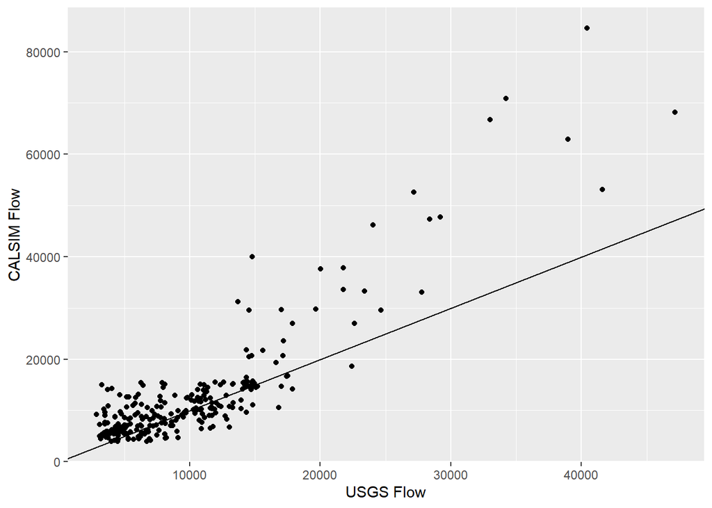

```r
combined_flows <- calsim_flows %>%
  left_join(kwk_monthly, by = c("date"="date"))

combined_flows %>%
  ggplot(aes(usgs_flow_avg, flow_cfs)) + geom_point() +
  geom_abline(slope = 1, intercept = 0) +
  # geom_smooth(method = "lm", formula = y ~ poly(x, 2)) +
  labs(x = "USGS Flow", y = "CALSIM Flow")
```

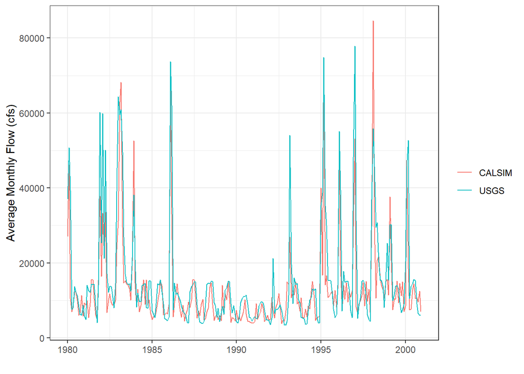

```r
combined_flows %>%
  ggplot() +
  geom_line(aes(date, flow_cfs, color = "CALSIM")) +
  geom_line(aes(date, usgs_flow_max, color = "USGS")) +
  labs(x = "", y = "Average Monthly Flow (cfs)",
       color = "") +
  theme_bw()
```

We can build a regression line from this relationship.

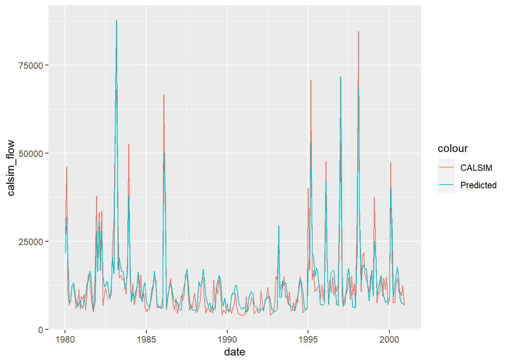

```r
m <- lm(flow_cfs ~ poly(usgs_flow_avg, 2), data = combined_flows)

predicted_month_flows <- tibble(
  date = combined_flows$date,
  calsim_flow = combined_flows$flow_cfs,
  predicted_flow = m$fitted.values
)

predicted_month_flows %>%
  ggplot() +
  geom_line(aes(date, calsim_flow, color = "CALSIM")) +
  geom_line(aes(date, predicted_flow, color = "Predicted"))
```

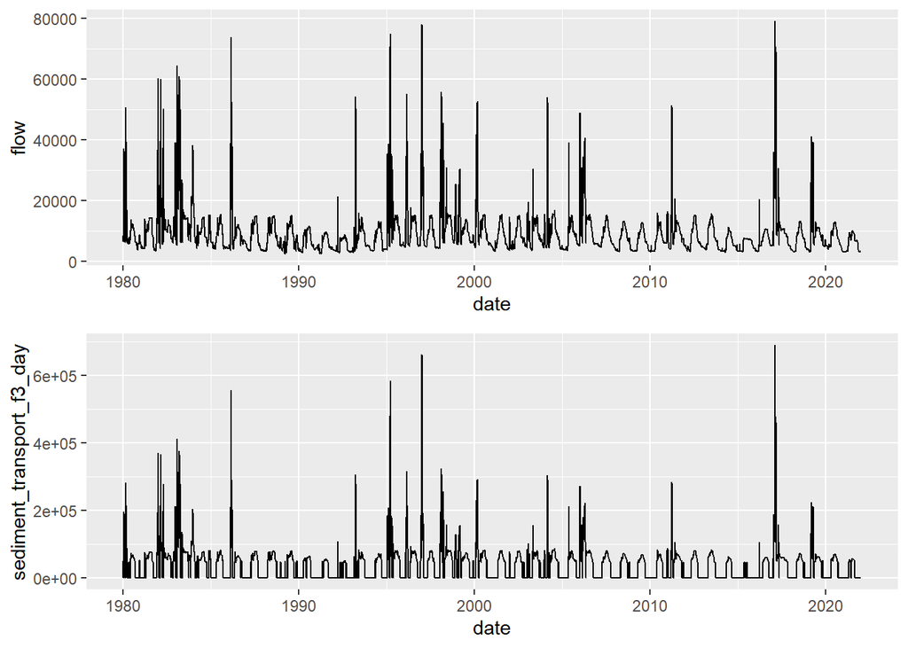

```r
usgs_flow_plot <- ggplot(kwk_sed_transport, aes(date, flow)) + geom_line()
sed_transport_plot <- ggplot(kwk_sed_transport, aes(date, sediment_transport_f3_day)) + geom_line()

grid.arrange(usgs_flow_plot, sed_transport_plot, nrow=2)
```

## Simulate Years of Decay

To simulate decay based on our curves we can simply set a starting point, apply daily USGS flows to accumulate loss and subtract this loss from our “starting point”

```r
# starting_volume <- 66.9 * (43560) * 2
# starting_vol <- 66.9 * (43560) * 2

# starting volume is in square meters
starting_volume <- (254690.3 * 10.764) * 2

kwk_sed_transport_sim <- kwk_sed_transport %>%
  filter(date >= "2015-01-01", date <= "2017-01-01") %>%
  mutate(sediment_transport_f3_day = ifelse(is.na(sediment_transport_f3_day), 0, sediment_transport_f3_day),
         sediment_transport_f3_day_accum = cumsum(sediment_transport_f3_day),
         start_vol = starting_volume,
         current_vol = start_vol - sediment_transport_f3_day_accum)
```

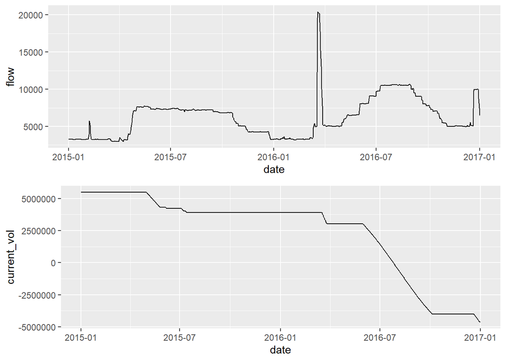

```r
p1 <- kwk_sed_transport_sim %>%
  ggplot() +
  geom_line(aes(date, current_vol))
p2 <- kwk_sed_transport_sim %>%
  ggplot() +
  geom_line(aes(date, flow))

grid.arrange(p2, p1, nrow = 2)
```

## Calibrate

```r
calib_func <- function(threshold) {
  scaled_sed_transport <- rating_curve$sed_ft3_per_day_min *
    d50_scaledown_summarized$avg_fraction

  calib_sed_curve <- approxfun(rating_curve$flow_cfs,
                         rating_curve$sed_ft3_per_day_min *
                           rep(threshold,
                               length(rating_curve$flow_cfs)))

  # convert square meters to cubic feet, assume 2ft depth
  starting_volume <- (254690.3 * 10.764) * 2

  calib_kwk_sed_transport <- tibble(
    date = kwk_usgs$Date,
    flow = kwk_usgs$Flow,
    sediment_transport_f3_day = calib_sed_curve(flow)
  ) %>%
    mutate(sediment_transport_f3_day = ifelse(is.na(sediment_transport_f3_day), 0, sediment_transport_f3_day))


  calib_kwk_sed_transport_sim <- calib_kwk_sed_transport %>%
    filter(date >= "2015-01-01", date <= "2017-04-01") %>%
    mutate(sediment_transport_f3_day = ifelse(is.na(sediment_transport_f3_day), 0, sediment_transport_f3_day),
           sediment_transport_f3_day_accum = cumsum(sediment_transport_f3_day),
           current_vol = starting_volume - sediment_transport_f3_day_accum)

  last_volume <- calib_kwk_sed_transport_sim %>% tail(1) %>% pull(current_vol)

  abs(last_volume - 0)
}


# We want to optimize the function by the threshold value that results
# in the volumne nearest zero.
result <- optimise(calib_func, interval = c(0, 1), maximum = FALSE)
```

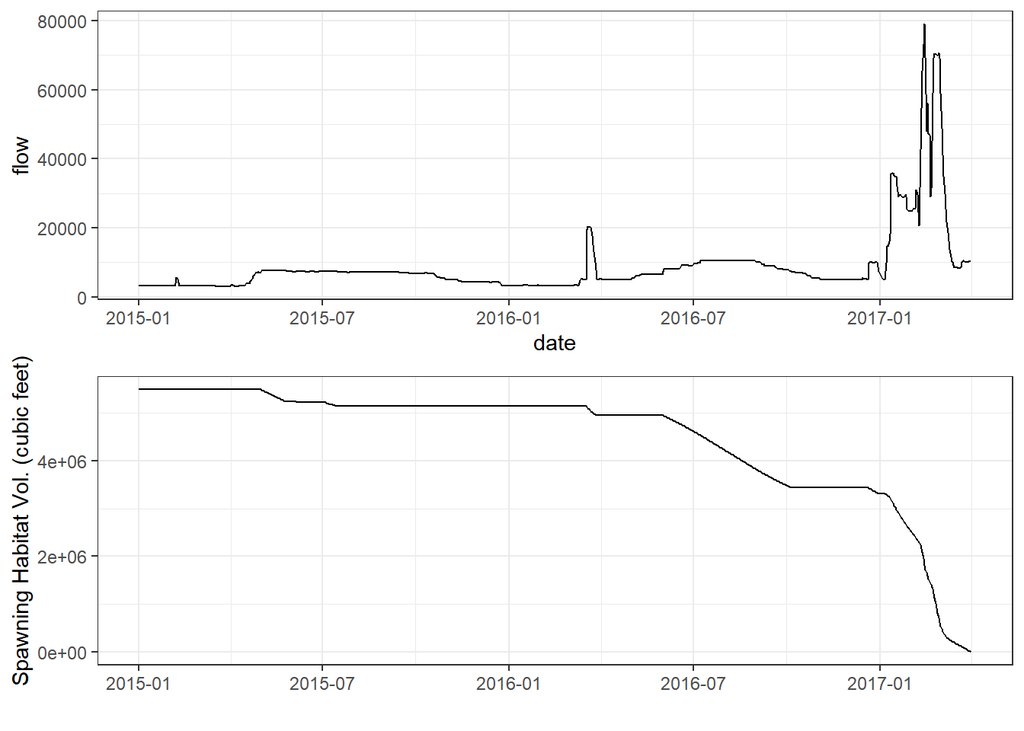

```r
flow_cfs_to_sed_cfd_calibrated <- approxfun(
  x = rating_curve$flow_cfs,
  y = rating_curve$sed_ft3_per_day_min * rep(result$minimum,
 length(rating_curve$flow_cfs))
)

calibrated_kwk_sed_transport <- tibble(
  date = kwk_usgs$Date,
  flow = kwk_usgs$Flow,
  sediment_transport_f3_day = flow_cfs_to_sed_cfd_calibrated(flow)
) %>%
  mutate(sediment_transport_f3_day = ifelse(is.na(sediment_transport_f3_day), 0, sediment_transport_f3_day))


starting_volume <- (254690.3 * 10.764) * 2

# add 20000 tons

kwk_sed_transport_sim <- calibrated_kwk_sed_transport %>%
  filter(date >= "2015-01-01", date <= "2017-04-01") %>%
  mutate(sediment_transport_f3_day = ifelse(is.na(sediment_transport_f3_day), 0, sediment_transport_f3_day),
         sediment_transport_f3_day_accum = cumsum(sediment_transport_f3_day),
         start_vol = starting_volume,
         current_vol = start_vol - sediment_transport_f3_day_accum)

p1 <- kwk_sed_transport_sim %>%
  ggplot() +
  geom_line(aes(date, current_vol)) +
  labs(x = "", y = "Spawning Habitat Vol. (cubic feet)") +
  theme_bw()

p2 <- kwk_sed_transport %>%
  filter(date >= "2015-01-01", date <= "2017-04-01") %>% ggplot(aes(date, flow)) + geom_line() +
  theme_bw()

grid.arrange(p2, p1, nrow = 2)
```